# Data Work for Economics Research

Iddo Glass

August 2026

These are notes from working with data for economics research projects, mainly in R and often with spatial data.

# Project workflow

**Work in R projects.** This makes relative paths more stable. Functions like `here::here()` refer to files from the project root, instead of relying on whatever folder happens to be active.

**Use version control.** Set up git + GitHub when you create the R project ([guide here](https://rfortherestofus.com/2021/02/how-to-use-git-github-with-r)). Make small commits with messages that explain the change, and use branches or pull requests when the project has several people or when a change is risky. Data files (especially heavy ones) and private files should usually go in `.gitignore`.

A project structure can look like:

| Folder or file | What goes there | Notes |
| --- | --- | --- |
| `data/raw/` | Original downloads | Do not edit |
| `data/intermediate/` | Cleaned or partially constructed files | Temporary datasets before joins or further manipulation |
| `data/final/` | Analysis-ready datasets |  |
| `do/` | `01_import`, `02_clean`, `03_construct`, `04_analysis`, etc. | Use names that show the order and purpose |
| `setup.R` | Packages, options, shared paths, and common functions | Source it near the start of scripts that need the same setup |
| `output/` | Tables, figures, maps, reports |  |

**Set an arbitrary recorded seed.** Fixed seeds are useful because they make random steps reproducible, but avoid defaults like `set.seed(123)` that can be copied without thought. See [this blog post](https://blog.genesmindsmachines.com/p/if-your-random-seed-is-42-i-will). One option is to choose a seed once (e.g., based on the starting date of the project), record it, and then keep using that same seed throughout the project.

## AI workflow

For R-specific skill files, see [this guide](https://rworks.dev/posts/claude-skills-for-r-users/).

For a broader AI workflow for economics projects, see [Scott Cunningham’s workflow](https://github.com/scunning1975/mixtapetools).

**You can use skills for both reusable preferences and project-specific context.** This helps when switching between projects. General instructions can be adjusted for project-specific context (e.g., if the coding style in a specific project is somewhat different from the generic one). An example structure is:

```
ai_instructions/
  general/
    coding_style.md
    data_checks.md
    writing_style.md
  project/
    context.md
    pipeline.md
    datasets.md
```

| File group | What belongs there | When it helps |
| --- | --- | --- |
| General files | Coding conventions, recurring checks, and writing preferences | When the same preferences apply across several projects |
| Project files | Question, unit of observation, key datasets, code structure, known edge cases, etc. | For most large projects |
| Project-specific conventions | Modified versions of the general files | When projects have specific rules for general preferences |

**Ask the AI to verify understanding.** Lean prompts are often fine when the context is already clear. For tasks that are not obvious, I prefer to ask the AI to interview me briefly before implementing, or restate the task. Often, I ask it to generate a prompt, then review it and submit in a new chat.

# Working in R

## Style

I mainly use `tidyverse` (and `dplyr`) because I like its syntax and pipe-friendly style, and out of habit. Thus the examples are largely going to use it.

**I often load packages with `pacman::p_load`,** which is cleaner than many lines of `library()` and installs packages that are not loaded.

```r
if (!require(pacman)) install.packages('pacman', repos = 'https://cran.rstudio.com')
pacman::p_load(dplyr, labelled, sjlabelled, tidyr, ggplot2, scales, sf,
  here, readr, dtplyr, duckdb, DBI, rnaturalearth
)

options(scipen = 999)
```

**Check package updates** for packages that you use often (e.g., `dplyr`), as new versions can add improved functions. However, automatic updates can be risky if an update changes the behaviour of existing functions.

I also use the new pipe (`|>`), which is cleaner than the magrittr `%>%` pipe.

As an example of how coding style changes over time, see the difference between the following styles. The first one uses the older `dplyr` style:

```r
example_df %>%
  group_by(iso2) %>%
  summarise(
    avg_gdp = mean(gdp_t)
  ) %>%
  ungroup()
```

Or, a bit cleaner:

```r
example_df |>
  summarise(
    avg_gdp = mean(gdp_t),
    .by = iso2
  )
```

## Speed

`dplyr` is rather fast for most operations. For most of my work, the difference was not large enough to matter. Still, there are faster alternatives:

| Tool | What it is | When to use |
| --- | --- | --- |
| `data.table` | Fast data-manipulation syntax | When you prefer its syntax or need more speed |
| `dtplyr` | Translates `dplyr` code to `data.table` | When you want `dplyr` syntax with more speed |
| `duckdb` | An in-process SQL database | When data is too large for memory |

An example:

```r
set.seed(23072026) # date of project start

speed_df <- tibble::tibble(
  iso2 = sample(sprintf("C%03d", 1:200), 3000000, replace = TRUE),
  year = sample(2000:2024, 3000000, replace = TRUE),
  gdp_t = runif(3000000, 1, 100),
  pop_m = runif(3000000, 1, 1500)
)

dplyr_elapsed <- system.time({
  dplyr_result <- speed_df |>
    mutate(
      gdp_pc = gdp_t * 1000000 / pop_m,
      large = gdp_t > 50
    ) |>
    filter(large, year >= 2010) |>
    summarise(
      avg_gdp_pc = mean(gdp_pc),
      total_gdp = sum(gdp_t),
      n = n(),
      .by = c(iso2, year)
      )
})[["elapsed"]]

cat("dplyr elapsed:", round(dplyr_elapsed, 3), "seconds\n")
```

```
## dplyr elapsed: 0.64 seconds
```

```r
dtplyr_elapsed <- system.time({
  dtplyr_result <- speed_df |>
    lazy_dt() |>
    mutate(
      gdp_pc = gdp_t * 1000000 / pop_m,
      large = gdp_t > 50
    ) |>
    filter(large, year >= 2010) |>
    summarise(
      avg_gdp_pc = mean(gdp_pc),
      total_gdp = sum(gdp_t),
      n = n(),
      .by = c(iso2, year)
      ) |>
    as_tibble()
})[["elapsed"]]

cat("dtplyr elapsed:", round(dtplyr_elapsed, 3), "seconds\n")
```

```
## dtplyr elapsed: 0.41 seconds
```

```r
con <- dbConnect(duckdb())
duckdb_register(con, "speed_df", speed_df)

duckdb_elapsed <- system.time({
  duckdb_result <- dbGetQuery(
    con,
    "
    SELECT
      iso2,
      year,
      AVG(gdp_t * 1000000 / pop_m) AS avg_gdp_pc,
      SUM(gdp_t) AS total_gdp,
      COUNT(*) AS n
    FROM speed_df
    WHERE gdp_t > 50
      AND year >= 2010
    GROUP BY iso2, year
    "
  )
})[["elapsed"]]

cat("duckdb elapsed:", round(duckdb_elapsed, 3), "seconds\n")
```

```
## duckdb elapsed: 0.16 seconds
```

```r
dbDisconnect(con, shutdown = TRUE)
```

For many operations, the difference is very small, and the setup might take longer than the calculation.

## Functions with the same names

Some R functions from different packages have **identical names, which can create bugs** that may be hard to spot. For example, take the `lag` function. `stats::lag` can produce confusing results, while it might be the default `lag`. `dplyr::lag` (or `data.table::shift(type = "lag")`) are clearer and more reliable.

```r
lag_example <- tibble::tibble(
  year = 2020:2022,
  gdp = c(100, 120, 140)
)

lag_example |>
  mutate(
    `dplyr::lag` = dplyr::lag(gdp),
    `stats::lag` = as.numeric(stats::lag(gdp))
  )
```

```
## # A tibble: 3 × 4
##    year   gdp `dplyr::lag` `stats::lag`
##   <int> <dbl>        <dbl>        <dbl>
## 1  2020   100           NA          100
## 2  2021   120          100          120
## 3  2022   140          120          140
```

Similarly, if code uses `select` without specifying `dplyr::select`, and `raster` has also been loaded, the code might call `raster::select` instead (at least that tends to break with a warning).

Another example is `copy_labels`, which exists in both `sjlabelled` and `labelled`. The two versions do not use the same argument order, and they may change values while copying labels, so in those cases write the package name explicitly (ideally in the setup file) and check the documentation.

# Data construction

## Working with country-level data

A lot of the analysis I have done is at the country level. Much of this analysis is similar when using other units of analysis.

**Use ISO codes rather than names.** Country names work well in plots and tables, but they are often inconsistent across datasets. For example, “Ivory Coast” and “Cote d’Ivoire” may refer to the same country. Thus, I prefer to use ISO codes (e.g., CIV). However, ISO codes also have limitations: South Sudan’s ISO3 may appear as `SSD` in one source and `SDS` in another; Namibia’s ISO2 code is `NA`, which can be read as missing data; and aggregates, disputed areas, territories, and historical countries can create other problems.

For illustration, I use WDI population and constant-dollar GDP files, and want to keep all countries. I convert the ISO3 codes to ISO2 with the `countrycode` package, then inspect the rows that failed conversion.

Most failed conversions are aggregates, such as regions and income, but there is also a country that fails the conversion: Kosovo, which is not mapped by default here. Thus, I map it manually:

| Raw label | ISO3 | ISO2 conversion | Decision | Why |
| --- | --- | --- | --- | --- |
| United States | `USA` | `US` | keep | ordinary country |
| Kosovo | `XKX` | `failed` | manual code XK | special case |
| Low income | `LIC` | `failed` | drop | aggregate |

```r
country_panel <- country_panel_all |>
  mutate(
    iso2 = if_else(iso3 == "XKX", "XK", iso2)
  ) |>
  filter_out(is.na(iso2)) # filter_out is a new dplyr function
```

**Geographic units do not always keep the same boundaries over time.** Countries change borders, gain independence, or split; this is also true for administrative units. Various datasets handle those changes differently. A value in a given year might refer to current borders, old borders, or something in between. Around the period of analysis, `Sudan` might mean present-day Sudan, or also include South Sudan. Kosovo - if it even appears in the data - might be under the rows of Yugoslavia (until 2003), Serbia and Montenegro (2003-2006), Serbia (2006-2008), or as Kosovo (generally 2008-, but in various datasets might appear as independent only from a later year). Taiwan and Palestine can also be coded or named in different ways depending on the source. Check the metadata to verify those cases.

## Join keys, merge types, and row multiplication

Quite often we need to join datasets using one or more common keys. My default is to work with a master dataset that includes the units used in the final analysis, and then add variables to it with `left_join()`. I use the other joins mostly for filtering and diagnostics:

| Join | What it does | Use |
| --- | --- | --- |
| `left_join()` | Keeps master rows and adds variables | Main construction |
| `inner_join()` | Keeps rows that match in both datasets | Filtering |
| `anti_join()` | Finds rows that do not match | Diagnostics |
| `full_join()` | Keeps rows from both datasets | Coverage checks |
| `semi_join()` | Keeps master rows with a match | Rarely |
| `right_join()` | Keeps rows from the added dataset | Rarely |

I mainly use the first three in ordinary construction scripts.

For example, the GDP figures below are 2024 real GDP in billions of constant 2015 US dollars from the World Bank file used above, rounded to the nearest billion:

Master data

| ISO3 | Region |
| --- | --- |
| USA | N. America |
| CHN | E. Asia |
| IND | S. Asia |
| MEX | L. America |

Added GDP data

| ISO3 | GDP |
| --- | --- |
| USA | 22,731 |
| CHN | 18,484 |
| IND | 3,434 |
| DEU | 3,677 |

`left_join()`

Keeps the master rows. Mexico stays, but GDP is missing

| ISO3 | Region | GDP |
| --- | --- | --- |
| USA | N. America | 22,731 |
| CHN | E. Asia | 18,484 |
| IND | S. Asia | 3,434 |
| MEX | L. America | NA |

`inner_join()`

Keeps only rows that match in both files

| ISO3 | Region | GDP |
| --- | --- | --- |
| USA | N. America | 22,731 |
| CHN | E. Asia | 18,484 |
| IND | S. Asia | 3,434 |

`full_join()`

Keeps everything from both files. Good for checking coverage

| ISO3 | Region | GDP |
| --- | --- | --- |
| USA | N. America | 22,731 |
| CHN | E. Asia | 18,484 |
| IND | S. Asia | 3,434 |
| MEX | L. America | NA |
| DEU | NA | 3,677 |

Before joining, check the unit of observation, whether the keys are unique at that level, unmatched rows, and missing values created by the join. Also look for accidental duplicate columns like `country_name.x` and `country_name.y`.

# Variable construction

Once the rows and keys are under control, the next problems are definitions, labels, units, missing values, aggregation rules, and derived variables.

## Definitions, units, and derived variables

Pay attention to definitions and units. For example, `gdp` could mean nominal GDP in current local currency, nominal GDP in current USD, real GDP in constant USD, or PPP-adjusted GDP.

## Aggregation rules and aggregate units

**Notice what aggregates contain and their names.** In some datasets there may be aggregates (e.g., “Middle East” in a country-level dataset), and their names can differ across datasets. In FAOSTAT, [one dataset](https://www.fao.org/faostat/en/#data/FBSH) has an aggregate called “Low Income Food Deficit Countries”, while [another](https://www.fao.org/faostat/en/#data/QCL) uses “Low Income Food Deficit Countries (LIFDCs)”. Since there is not always an ISO2/3 equivalent for each aggregate, pay attention to those cases.

## Missing values

Missing values can mean different things, such as: the value was not collected, it was not applicable, it failed to merge, it is unknown, and so on. It generally appears as `NA`, but `NaN` would appear after undefined numeric operations (such as `0 / 0`); `NULL` usually means that an object (rather than a single cell) is absent.

**Missing values need an explicit rule.** During construction, first try to understand why they are missing. Then decide whether to leave them as missing or replace them using a documented rule justified by the project. Suppose that NAs mean missingness, and we want to sum GDP over 2023-2025 for each country:

| Country | 2023 | 2024 | 2025 |
| --- | --- | --- | --- |
| Bolivia | 42.1 | 43.0 | NA |
| Cuba | NA | NA | NA |
| Eritrea | 2.3 | NA | 2.5 |

The main choices are:

**`na.rm = TRUE`**

Use the observed values. For sums, an all-missing country returns 0, which may be misleading

**`na.rm = FALSE`**

Return `NA` if any value is missing. This is strict, but can erase usable partial information.

**NA only if all missing**

Use observed values when at least one exists, but keep fully missing countries as missing

| Country | Observed years | Sum rule `na.rm = TRUE` | Sum rule `na.rm = FALSE` | Sum rule NA only if all missing |
| --- | --- | --- | --- | --- |
| Bolivia | 2 of 3 | 85.1 | NA | 85.1 |
| Cuba | 0 of 3 | 0.0 | NA | NA |
| Eritrea | 2 of 3 | 4.8 | NA | 4.8 |

Choose the rule explicitly, and show the amount of missingness next to the aggregate if relevant:

```r
df |>
  summarise(
    total = if (all(is.na(x))) NA_real_ else sum(x, na.rm = TRUE),
    n_observed = sum(!is.na(x)),
    .by = group
  )
```

# Validation

**Run checks after important construction steps,** such as joins, aggregations, spatial matches, and output construction.

## Messages and quick checks

**Add short messages after certain construction steps,** to make mistakes easier to notice. This can make the code harder to read, but it has some value when used sparingly. AI tools can also run these checks and report the results. For example:

```r
joined_country_regions <- country_regions |>
  left_join(
    country_gdp |>
      select(-country_name),
    join_by(iso3)
  )

unmatched_country_regions <- country_regions |>
  filter_out(iso3 %in% country_gdp$iso3)

message(
  n_distinct(country_regions$iso3) - nrow(unmatched_country_regions), " of ",
  n_distinct(country_regions$iso3), " country-region units matched to GDP."
)
```

```
## 3 of 4 country-region units matched to GDP.
```

```r
message(
  nrow(unmatched_country_regions), " country-region units did not match to GDP."
)
```

```
## 1 country-region units did not match to GDP.
```

```r
message(
  sum(is.na(joined_country_regions$gdp_b)), " rows have missing GDP after the join."
)
```

```
## 1 rows have missing GDP after the join.
```

## Checks after construction steps

| After this step | What to check | Example message |
| --- | --- | --- |
| Join | Expected unit of observation; row counts before and after; unmatched keys; missingness in new variables | 247 of 250 country-year rows matched; 3 unmatched ISO3 codes. |
| Aggregation | Rows collapsed per group; groups with all missing inputs; unexpected zeros or extreme totals | Collapsed 12,500 rows to 250 groups; 4 groups have all-missing GDP. |
| Spatial match | Unmatched points or polygons; multiple matches; a map of matched and unmatched units | 98.6% of points matched to an admin unit; 42 points unmatched. |
| Output construction | Expected file exists; row count, column count, CRS, and key variables are present | Wrote final_country_panel.rds with 5,250 rows and 37 columns. |

# Plots

To me, plots in economic research have two main jobs. First, **inspecting the data**. These plots can be simple because the goal is to understand the data and detect issues, such as implausible or missing values. Second, **presenting the results** and sharing the main insights. These plots should be clean, concise, and should reduce the effort required from the reader.

I highly recommend reading [Saloni Dattani’s guide to data visualization](https://www.scientificdiscovery.dev/p/salonis-guide-to-data-visualization).

Some tips that often help:

- Remove axis titles when the title already says what is plotted, when their meaning is implied (years), or when they are hard to read (most y-axes)
- Directly label a few important series instead of using a legend
- Grey out background series when the figure focuses on few important series
- You can add annotations when they clarify things (although they are annoying to code in R)
- Name a specific visualization guide when asking AI to generate plots. [Paul Goldsmith-Pinkham recommended using the following message in the prompt -](https://youtu.be/Rp17XUPxa4I?si=g7hzproWhXlKNzri&t=1393) `Please follow the best practices of making figures from Kieran Healy.`

The graph type should follow the question. This is a very partial list, but some examples:

| Graph type | Best for | Note |
| --- | --- | --- |
| Line | Changes over time | Good when order matters |
| Bar | Comparing categories | Can work well if there aren’t many categories |
| Stacked bar/area | Composition or totals | Can be hard to read |
| Pie | Rarely | Avoid in most cases - shares are hard to read |
| Scatter | Relationships between two variables | Good when order does not matter |
| Histogram/density | Distributions | Good for highlighting skew, outliers and bunching |

The next plots show the same data moving from a quick inspection graph to a cleaner presentation version.

A very basic version of a plot is:

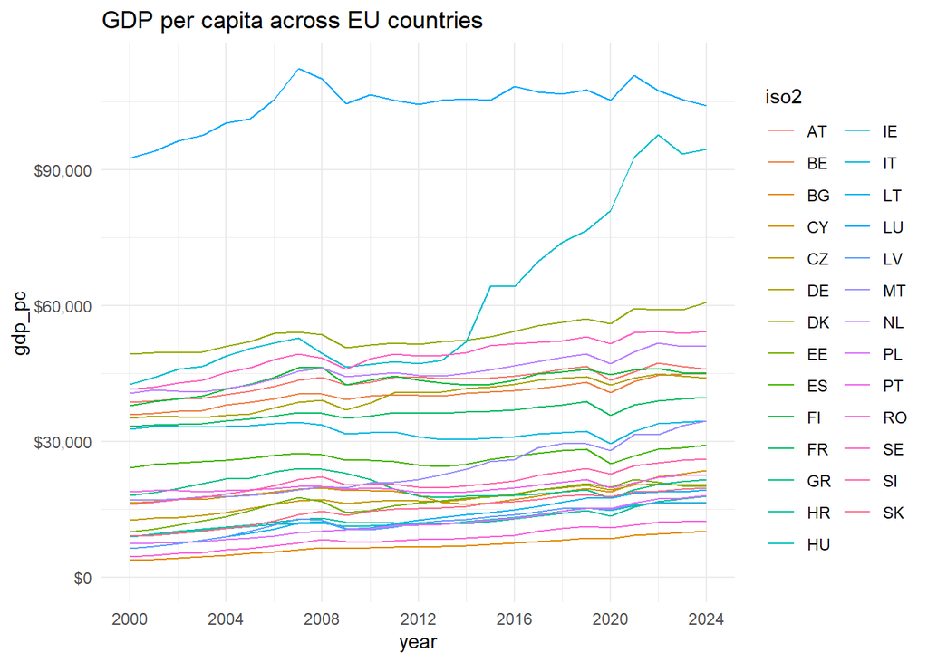

```r
plot_df |>
  ggplot() +
  geom_line(aes(x = year, y = gdp_pc, color = iso2)) +
  scale_x_continuous(breaks = seq(2000, 2024, 4), limits = c(2000, 2024)) +
  scale_y_continuous(limits = c(0, NA), labels = label_dollar()) +
  theme_minimal() +
  labs(title = "GDP per capita across EU countries")
```

The axis titles are unnecessary (‘gdp_pc’ is implied from the title, ‘year’ is easily understood), and that it’s extremely hard to understand which line refers to which country.

Suppose we want to focus on Ireland’s rise from Sweden’s level of GDP per capita to nearly Luxembourg’s. We can highlight those countries and keep the other EU countries in grey, and remove the axis titles and legend:

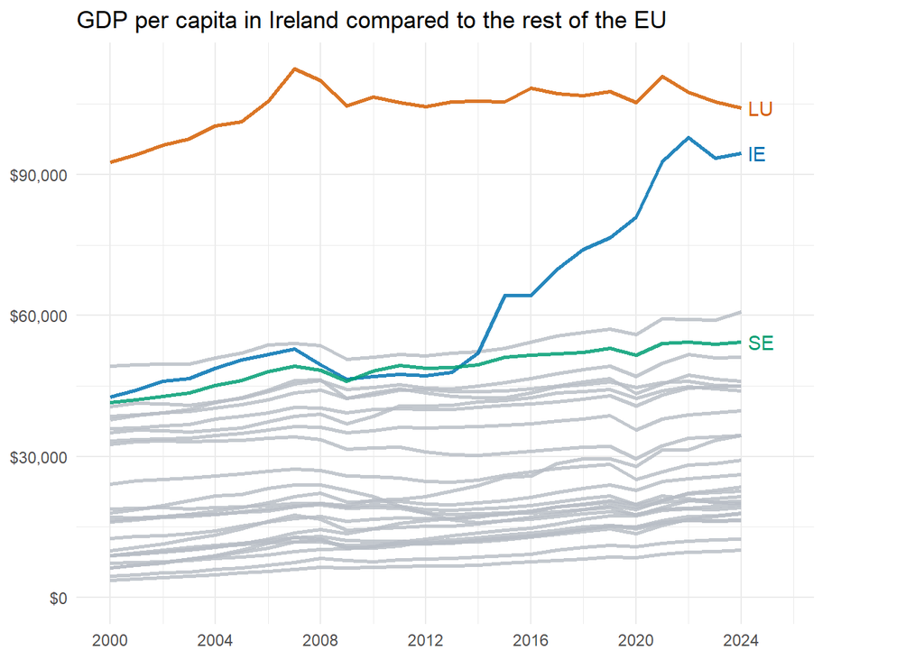

```r
plot_colors <- c(
  "IE" = "#0072B2",
  "LU" = "#D55E00",
  "SE" = "#009E73",
  "Other countries" = "#b8bec6"
)

line_labels <- plot_df |>
  filter(iso2 %in% highlight_countries) |>
  summarise(
    gdp_pc = gdp_pc[which.max(year)],
    year = max(year),
    label = country_name[which.max(year)],
    .by = iso2
  )

plot_df |>
  ggplot(aes(x = year, y = gdp_pc, group = iso2)) +
  geom_line(aes(color = highlighted), linewidth = 0.9, alpha = 0.85) +
  geom_text(
    data = line_labels,
    aes(label = iso2, color = iso2),
    hjust = 0,
    nudge_x = 0.25,
    show.legend = FALSE
  ) +
  scale_color_manual(values = plot_colors) +
  scale_x_continuous(breaks = seq(2000, 2024, 4), limits = c(2000, 2025.5)) +
  scale_y_continuous(limits = c(0, NA), labels = label_dollar()) +
  theme_minimal() +
  theme(
    axis.title = element_blank(),
    legend.position = "none",
    plot.margin = margin(5.5, 60, 5.5, 5.5)
  ) +
  coord_cartesian(clip = "off") +
  labs(title = "GDP per capita in Ireland compared to the rest of the EU")
```

That is already easier to read than many default plots. A more polished version can use a cleaner background, an informative title and subtitle, and country names instead of raw codes:

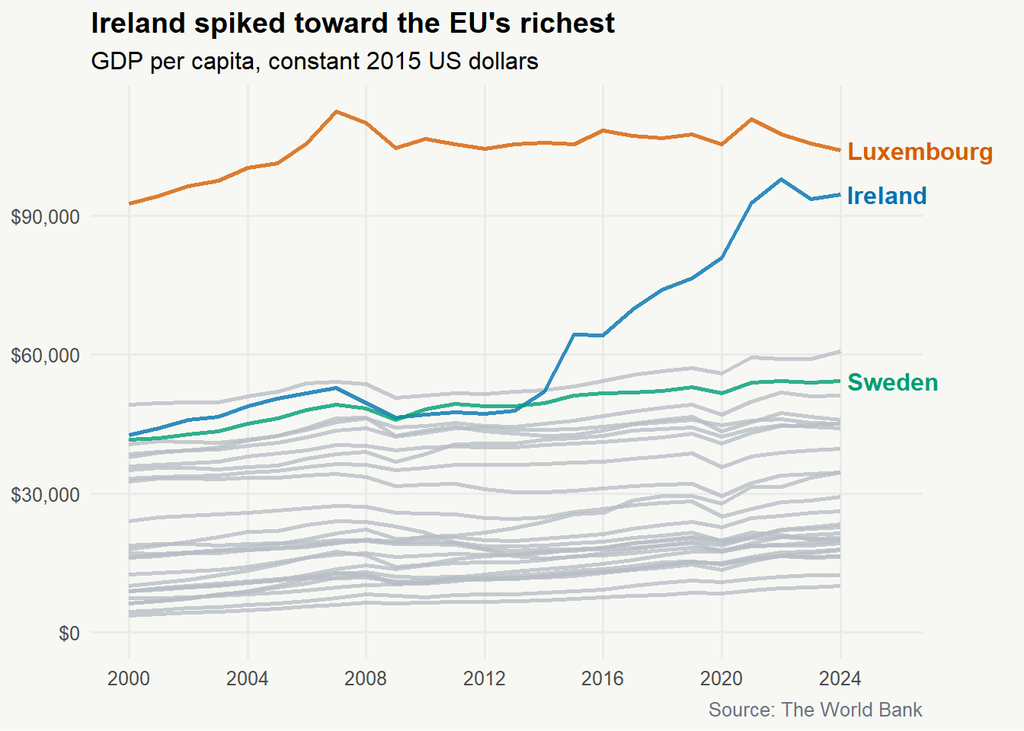

```r
plot_df |>
  ggplot(aes(x = year, y = gdp_pc, group = iso2)) +
  geom_line(aes(color = highlighted), linewidth = 0.9, alpha = 0.8) +
  geom_text(
    data = line_labels,
    aes(label = label, color = iso2),
    hjust = 0,
    nudge_x = 0.25,
    fontface = "bold",
    show.legend = FALSE
  ) +
  scale_color_manual(values = plot_colors) +
  scale_x_continuous(breaks = seq(2000, 2024, 4), limits = c(2000, 2025.5)) +
  scale_y_continuous(limits = c(0, NA), labels = label_dollar()) +
  labs(
    title = "Ireland spiked toward the EU's richest",
    subtitle = "GDP per capita, constant 2015 US dollars",
    caption = "Source: The World Bank"
  ) +
  theme_minimal(base_size = 12) +
  theme(
    axis.title = element_blank(),
    legend.position = "none",
    plot.background = element_rect(fill = "#f7f8f3", color = NA),
    panel.background = element_rect(fill = "#f7f8f3", color = NA),
    panel.grid.minor = element_blank(),
    plot.title = element_text(face = "bold"),
    plot.caption = element_text(color = "#6b7280"),
    plot.margin = margin(5.5, 50, 5.5, 5.5)
  ) +
  coord_cartesian(clip = "off")
```

# Spatial data

There are two main types of spatial datasets:

| Type | What it stores | Common examples | R package |
| --- | --- | --- | --- |
| Vector | Points, lines, or polygons | Boundaries, roads, locations | `sf` |
| Raster | Values in grid cells | Climate, elevation, population | `terra` |

**For vector data in R, use `sf`.** Most of the time, `sf::read_sf()` and `sf::write_sf()` are convenient wrappers around `st_read()` and `st_write()`, unless a file has many layers. Vector data is often saved as shapefiles. Shapefiles are split across several files (`.shp`, `.shx`, `.dbf`, etc.) and have short column-name limits. Use geopackages (`.gpkg`) when possible. They are more efficient and easier to work with.

**For raster data in R, use `terra`.** Raster data is often saved as `.tif`, especially for ordinary gridded layers. Another common format is `.nc` or NetCDF, which is often used for climate data.

Pay attention to CRS and projections. A CRS tells R how coordinates on the screen relate to places on Earth. Areas, distances, buffers, and centroids can be misleading if the data are in longitude/latitude or if layers use different CRS, so check `st_crs()`/`crs()` and use `st_transform` when needed to a projection that makes sense for the operation.

## Which tool to use

| Tool | Examples | Main advantages | Main drawbacks |
| --- | --- | --- | --- |
| Programming languages | R, Python | Easy to combine with cleaning and modeling, and with AI | Storage, memory, and visual inspection |
| GIS software | QGIS, ArcGIS | Visual inspection, manual exploration | Less convenient for scripted workflows |
| Google Earth Engine | Code Editor, Python API | Hosted catalogs and large raster summaries | Quotas and server-side debugging |

Several notes on GIS software and GEE:

- ArcGIS is powerful but not free
- You can also program inside GIS tools, but I find that less convenient than `sf` and `terra` in R
- GEE is best when the data already exists in the [Earth Engine data catalog](https://developers.google.com/earth-engine/datasets/) or the [GEE community catalog](https://gee-community-catalog.org/) - such as Hansen forest loss data or GHSL built-up - as you avoid downloading and storing large rasters
- The coding experience in GEE is more annoying, but there’s now a Gemini assistant there (which requires a Gemini API key, so is not unlimited).
- GEE’s new quotas are still usually enough for spatial aggregations, but more limited for heavier work such as geometric operations
- For GEE, using the Python API can keep the spatial step in the same project workflow, but it’s harder to visually debug; you can start in the GEE code editor and let an AI convert it to Python when done (verify that outputs are identical)

When unsure, AI can help consider the trade-offs. Since trying a small R version is now cheap, start there and check whether it is fast enough.

### Recommendations for working with GEE

- If the same spatial units appear in several scripts, create one master feature collection, such as `var worldUnits = ee.FeatureCollection('projects/ee-your_project/assets/worldUnits');`. Then each script can call the same cleaned units.
- If AI suggests a boundary dataset such as [`FAO/GAUL/2015/level0`](https://developers.google.com/earth-engine/datasets/catalog/FAO_GAUL_2015_level0), check whether territories or administrative units need to be merged before grouping by ISO3. Country-level comparisons can be wrong if the boundary file uses different units.
- If the boundary file needs cleaning, use a separate GEE script to clean names, match to ISO3, merge units, and export a reusable asset. Analysis scripts stay shorter and call the same version of the cleaned boundary file.

# Maps

For maps in R, `ggplot2` with `geom_sf()` is often enough. A choropleth map needs two inputs: boundaries and a variable to color each area.

This example first highlights a bug. If we join by ISO2, France is not matched because the `rnaturalearth` file uses `-99` as its ISO2 code (as France has several territories).

```r
eu_gdp_2024 <- country_panel |>
  filter(year == 2024, iso2 %in% eu27_countries) |>
  mutate(gdp_pc = gdp_b * 1000 / pop_m) |>
  select(iso2, iso3, gdp_pc)

europe_boundaries <- rnaturalearth::ne_countries(
  scale = "small",
  returnclass = "sf"
) |>
  select(iso2 = iso_a2, iso3 = adm0_a3, continent, geometry) |>
  filter(continent == "Europe")

iso2_join_diagnostic <- europe_boundaries |>
  mutate(in_eu = iso2 %in% eu27_countries) |>
  left_join(
    eu_gdp_2024 |> select(iso2, gdp_pc),
    join_by(iso2)
  )

iso2_join_diagnostic |>
  filter(iso3 %in% c("FRA", "DEU", "ESP")) |>
  st_drop_geometry() |>
  select(iso2_boundary = iso2, iso3, in_eu, gdp_pc)
```

```
##   iso2_boundary iso3 in_eu   gdp_pc
## 1           -99  FRA FALSE       NA
## 2            DE  DEU  TRUE 44027.55
## 3            ES  ESP  TRUE 29245.12
```

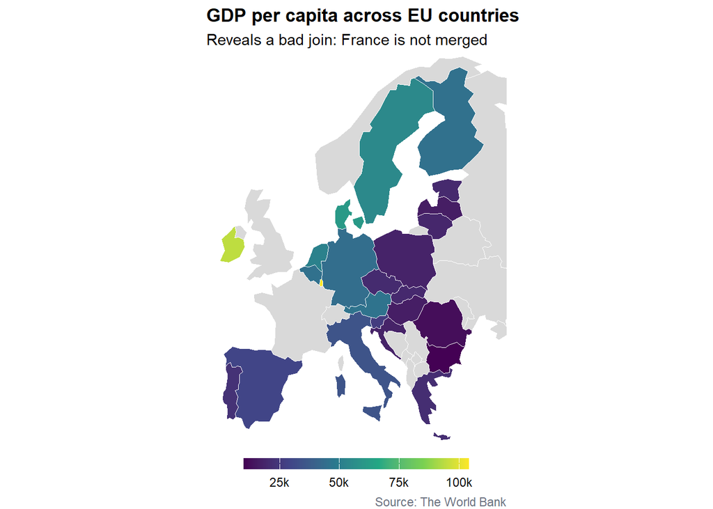

```r
iso2_join_diagnostic |>
  ggplot() +
  geom_sf(fill = "#d9d9d9", color = "white", linewidth = 0.12) +
  geom_sf(
    data = iso2_join_diagnostic |> filter(in_eu),
    aes(fill = gdp_pc),
    color = "white",
    linewidth = 0.12
  ) +
  scale_fill_viridis_c(
    labels = label_number(scale = 1 / 1000, suffix = "k"),
    na.value = "#eeeeee",
    guide = guide_colorbar(
      title = NULL,
      barwidth = grid::unit(160, "pt"),
      barheight = grid::unit(8, "pt"),
      label.position = "bottom"
    )
  ) +
  coord_sf(xlim = c(-12, 35), ylim = c(34, 72), expand = FALSE) +
  theme_void() +
  theme(
    legend.position = "bottom",
    plot.title = element_text(face = "bold"),
    plot.caption = element_text(color = "#6b7280")
  ) +
  labs(
    title = "GDP per capita across EU countries",
    subtitle = "Reveals a bad join: France is not merged",
    caption = "Source: The World Bank"
  )
```

The fix is to join by ISO3 in this case. For presentation, the scale depends on the comparison: continuous color, or binned values; and if binned, which bins? The first version keeps a wide top category, which emphasizes the richest countries such as Luxembourg and Ireland. The second version uses the same palette but compresses the top and gives more detail in the middle and bottom, making differences among countries with relatively lower incomes in the EU easier to see:

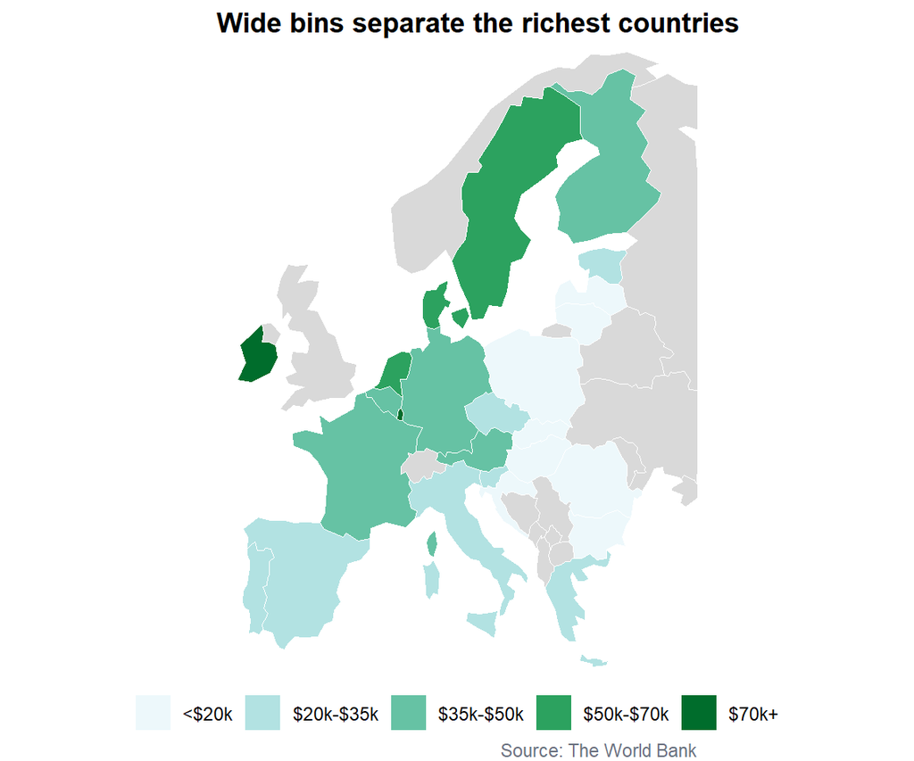

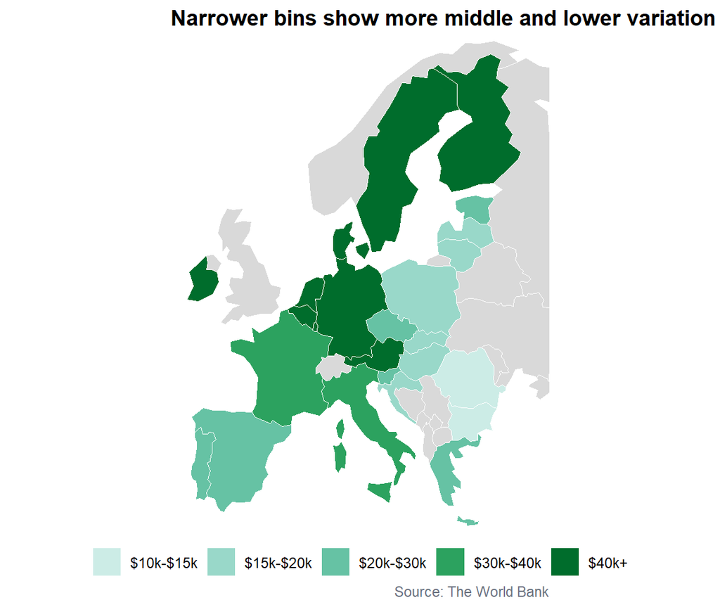

```r
eu_gdp_map <- europe_boundaries |>
  mutate(in_eu = iso3 %in% eu_gdp_2024$iso3) |>
  left_join(
    eu_gdp_2024 |> select(iso3, gdp_pc),
    join_by(iso3)
  ) |>
  mutate(
    gdp_pc_group_wide = cut(
      gdp_pc,
      breaks = c(0, 20000, 35000, 50000, 70000, Inf),
      labels = c("<$20k", "$20k-$35k", "$35k-$50k", "$50k-$70k", "$70k+"),
      right = FALSE
    ),
    gdp_pc_group_middle = cut(
      gdp_pc,
      breaks = c(0, 10000, 15000, 20000, 30000, 40000, Inf),
      labels = c("<$10k", "$10k-$15k", "$15k-$20k", "$20k-$30k", "$30k-$40k", "$40k+"),
      right = FALSE
    )
  )

eu_gdp_map |>
  ggplot() +
  geom_sf(fill = "#d9d9d9", color = "white", linewidth = 0.12) +
  geom_sf(
    data = eu_gdp_map |> filter(in_eu),
    aes(fill = gdp_pc_group_wide),
    color = "white",
    linewidth = 0.12
  ) +
  scale_fill_manual(
    values = c(
      "<$20k" = "#edf8fb",
      "$20k-$35k" = "#b2e2e2",
      "$35k-$50k" = "#66c2a4",
      "$50k-$70k" = "#2ca25f",
      "$70k+" = "#006d2c"
    ),
    na.value = "#eeeeee",
    name = NULL
  ) +
  coord_sf(xlim = c(-12, 35), ylim = c(34, 72), expand = FALSE) +
  theme_void() +
  theme(
    legend.position = "bottom",
    plot.title = element_text(face = "bold"),
    plot.caption = element_text(color = "#6b7280")
  ) +
  labs(
    title = "Wide bins separate the richest countries",
    caption = "Source: The World Bank"
  )

eu_gdp_map |>
  ggplot() +
  geom_sf(fill = "#d9d9d9", color = "white", linewidth = 0.12) +
  geom_sf(
    data = eu_gdp_map |> filter(in_eu),
    aes(fill = gdp_pc_group_middle),
    color = "white",
    linewidth = 0.12
  ) +
  scale_fill_manual(
    values = c(
      "<$10k" = "#edf8fb",
      "$10k-$15k" = "#ccece6",
      "$15k-$20k" = "#99d8c9",
      "$20k-$30k" = "#66c2a4",
      "$30k-$40k" = "#2ca25f",
      "$40k+" = "#006d2c"
    ),
    na.value = "#eeeeee",
    name = NULL
  ) +
  coord_sf(xlim = c(-12, 35), ylim = c(34, 72), expand = FALSE) +
  theme_void() +
  theme(
    legend.position = "bottom",
    plot.title = element_text(face = "bold"),
    plot.caption = element_text(color = "#6b7280")
  ) +
  labs(
    title = "Narrower bins show more middle and lower variation",
    caption = "Source: The World Bank"
  )
```

# Spatial matching

Spatial units often require join operations, and those joins require judgment calls. A unit may intersect several polygons, a point may fall just outside a boundary because the datasets use slightly different borders, or a raster cell may only partly overlap the polygon. We have several options, such as:

| Type | Usual pattern | Risk | Immediate check |
| --- | --- | --- | --- |
| Point to polygon | `st_join(…, st_within)` | Unmatched points; duplicate matches | Count unmatched and multiply matched points |
| Polygon overlap | `st_intersection()` | Rows multiply; area can be wrong | Check row counts and overlap shares |
| Nearest match | `st_nearest_feature()` or `nngeo::st_nn()` | A nearest feature can still be far away | Store distance and flag matches above a cutoff |
| Raster extraction | `terra::extract()` | Partial cells; wrong aggregation | Check weights and compare a few polygons |

If the polygons in one source can overlap each other, decide whether those overlaps should count once or several times before intersecting them with the units of analysis.

For example, overlay the Netherlands and Belgium with a 0.5 by 0.5 degree grid. Some grid cells cross the border. We can use `st_intersection()` to calculate the share of each cell that lies within each country:

```r
country_grid_overlap <- st_intersection(country_grid, countries) |>
  mutate(overlap_area_km2 = as.numeric(st_area(st_transform(geometry, 3035))) / 1e6)
```

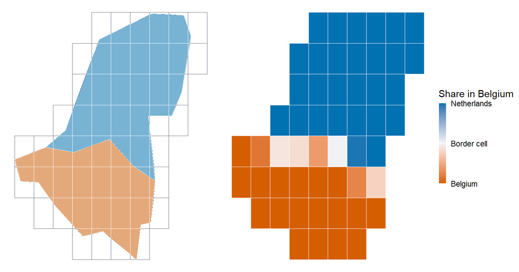

## Representative points of polygons

Sometimes we want to use one point for a unit rather than the full polygon. That is especially common when the analysis is heavy, for example calculating road paths between units, or when the question is about specific places inside the unit.

Which point should we use? It depends on what the point is meant to represent:

| Question | Point choice | Check before using it |
| --- | --- | --- |
| Where is the geometric center of this unit? | Centroid | Does it fall outside the polygon or in a useless empty area? |
| I need a point inside the polygon | `st_point_on_surface()` | Is the point substantively reasonable, not just technically inside? |
| Where is the average person in this unit? | Population-weighted centroid | Does the point fall between population centers or outside the unit? |
| What is the main populated place? | Highest-population cell or main city | Is the raster/city source at the right resolution for the project? |

This example uses a mock polygon with a hole and a population surface to highlight the difference in points:

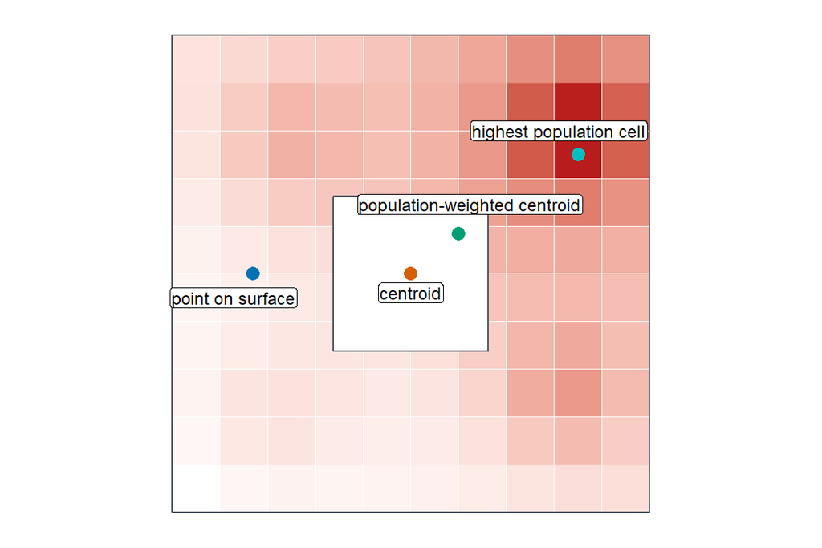